# Titration/Rule-Based Simulations

## Introduction

In the Simulation vignette several examples are provided using fixed dosing regimens. This works well for compounds that are relatively safe, the PK is consistent over time, and for which the drug concentrations required to achieve efficacy are consistent. In fact these restrictions apply to many different compounds. However, there are many scenarios where it is necessary to adjust dosing based on periodic clinical visits: compounds with a narrow therapeutic index, disease progression which alters the drug PK or requires increases in the dose amount, etc. While it is possible to do this manually with the current simulation tools provided, this section outlines a generalized framework to make this easier for the users. The [workshop](https://ubiquity-pkpd.s3-us-west-1.amazonaws.com/files/ubiquity_workshop.zip) provides several examples of running titration or rule-based simulations. To make a copy of these scripts and other supporting files in the current working directory run the following:

```r
library(ubiquity)
fr = workshop_fetch(section="Titration", overwrite=TRUE)
```

This should provide you with the following scripts:

- `analysis_repeat_dosing.r` - Implement fixed bolus dosing using the titration framework
- `analysis_repeat_infusion.r` - Implement fixed infusion rates using the titration framework
- `analysis_visit_dosing_titration.r` - Alter dosing based on predictions at specified time points (individual)
- `analysis_visit_dosing_titration_stochastic.r` - Alter dosing based on predictions at specified time points (population)
- `analysis_state_reset.r` - Combine multiple rules to dose the drug and perform a state reset

Titration or rule-based simulations are run using the following functions:

- `system_new_tt_rule()` - Defines a new rule and the times when it is evaluated
- `system_set_tt_cond()` - Adds a condition to a rule and an associated action to perform when that condition is true
- `run_simulation_titrate()` - Runs an individual simulation using titration rules

## Repeated Bolus Dosing (`analysis_repeat_dosing.r`)

This example shows how to implement a dosing regimen using both the fixed-dosing methodologies and the titration functions above. This is meant as a means to bridge these two concepts. First we use the same model from the Simulation vignette ([Davda etal. mAbs, 6(4), 1094-1102](https://doi.org/10.4161/mabs.29095)), and simulate five doses of 500 mg IV given every two weeks:

```r
cfg = build_system()
cfg = system_select_set(cfg, "default")
parameters = system_fetch_parameters(cfg)
cfg=system_set_option(cfg,group   = "simulation", option = "solver",       value = "lsoda")
cfg=system_set_option(cfg, group  = "simulation", option = "output_times",  seq(0,10*7,1))
cfg = system_zero_inputs(cfg)
cfg = system_set_bolus(cfg, state   = "Cc",
                            times   = c(0, 14, 28, 42, 56),
                            values  = c(500, 500, 500, 500, 500))
som_fix = run_simulation_ubiquity(parameters, cfg)
```

To use rule-based control of the simulation we have to enable the titration option:

```r
cfg=system_set_option(cfg,
                      group       = "titration",
                      option      = "titrate",
                      value       = TRUE)
```

Next we need to define a rule using `system_new_tt_rule()`. A rule contains a set of times (and the timescale) where we want to evaluate that rule. Here we create a rule called `"ivdose"` and we evaluate this rule at weeks 0, 2, 4, 6 and 8. Any timescale defined using `<TS:?>` in the system file can be used:

```r
cfg=system_new_tt_rule(cfg,
                       name       = "ivdose",
                       times      = c(0, 2, 4, 6, 8),
                       timescale  = "weeks")
```

Once a rule has been created you can attach conditions to that rule using `system_set_tt_cond()`. The name passed to this function is the name of the rule to which this condition applies. The `cond` argument is a string that will be evaluated internally. You put any kind of Boolean argument you want here, or even create a user definable function that returns a Boolean argument (eg, `'myfunction(arguments)'`). When this condition evaluates as true the string in `action` will be evaluated. The string `SI_TT_BOLUS` is a prototype function used to modify dosing at the titration points. See the help (`?system_set_tt_cond`) for details on prototype functions and the variables available in the titration environment. This action will define the dosing into the specified state (as defined by `<B:?>` in the system file) with the values and times shown. The units here are those specified in the system file and the times are relative to the titration time point.

```r
cfg=system_set_tt_cond(cfg,
                       name       = "ivdose",
                       cond       = "TRUE",
                       action     = "SI_TT_BOLUS[state='Cc', values=500, times=0]",
                       value      = "1")
```

Next we simulate the system using the titration function:

```r
som_tt = run_simulation_titrate(parameters, cfg)
```

Now we can overlay the predictions using both methods to show that they produce the same result:

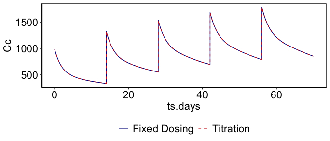

```r
 myfig = ggplot() +
         geom_line(data=som_fix$simout, aes(x=ts.days,   y=Cc, color="Fixed Dosing"), linetype=1) +
         geom_line(data=som_tt$simout,  aes(x=ts.days,   y=Cc, color="Titration"   ), linetype=2)  +
         scale_colour_manual(values=c("Fixed Dosing"="darkblue", "Titration"="firebrick3"))  +
         theme(legend.title = element_blank()) +
         theme(legend.position = 'bottom')

 myfig = prepare_figure('present', myfig)

 print(myfig)
```

## Repeated Infusions (`analysis_repeat_infusion.r`)

In this example we want to give a 30 minute infusion at 15 mg/min every two weeks. Similar to the previous example we first do this using the fixed dosing methods:

```r
cfg = system_zero_inputs(cfg)
cfg = system_set_rate(cfg, rate    = "Dinf",
                times   = c( 0, 30, 20160, 20190, 40320, 40350, 60480, 60510, 80640, 80670),
                levels  = c(15 , 0,    15,     0,    15,     0,    15,     0,    15,     0))
som_fix = run_simulation_ubiquity(parameters, cfg)
```

Now to use the rule-based dosing we enable titration, create the rule (`"ivdose"`) to hold the dosing times, and create the conditions resulting in the dosing. This is all similar to the previous example except we use the `SI_TT_RATE` prototype function. The rate and the units of times and levels are the same as those specified in the system file (`<R:?>`). The times here are also relative to the titration time.

```r
cfg=system_set_option(cfg, group = "titration", option = "titrate",        value     = TRUE)
cfg=system_new_tt_rule(cfg, name = "ivdose",    times  = c(0, 2, 4, 6, 8), timescale = "weeks")
```

```r
cfg=system_set_tt_cond(cfg,
                       name       = "ivdose",
                       cond       = "TRUE",
                       action     = "SI_TT_RATE[rate='Dinf', times=c(0,30), levels=c(15,0)]",
                       value      = "1")
```

```r
som_tt = run_simulation_titrate(parameters, cfg)
```

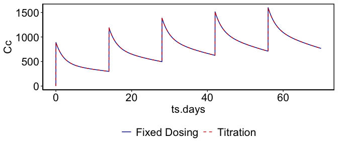

```r
 myfig = ggplot() +
         geom_line(data=som_fix$simout, aes(x=ts.days,   y=Cc, color="Fixed Dosing"), linetype=1) +
         geom_line(data=som_tt$simout,  aes(x=ts.days,   y=Cc, color="Titration"   ), linetype=2)  +
         scale_colour_manual(values=c("Fixed Dosing"="darkblue", "Titration"="firebrick3"))  +
         theme(legend.title = element_blank()) +
         theme(legend.position = 'bottom')

 myfig = prepare_figure('present', myfig)

 print(myfig)
```

## Titrated Dosing (`analysis_visit_dosing_titration.r`)

```r
cfg=system_new_tt_rule(cfg,
    name       = "ivdose",
    times      = c(0, 6, 12, 18, 24),
    timescale  = "months")
cfg=system_set_tt_cond(cfg,
    name   = "ivdose",
    cond   = "Cc < 900",
    action = "SI_TT_BOLUS[state='At', values=700, times=0, repdose='last', number=11, interval=14]",
    value  = "700")
cfg=system_set_tt_cond(cfg,
    name   = "ivdose",
    cond   = "Cc > 900",
    action = "SI_TT_BOLUS[state='At', values=600, times=0, repdose='last', number=11, interval=14]",
    value  = "600")

som_tt = run_simulation_titrate(parameters, cfg)
```

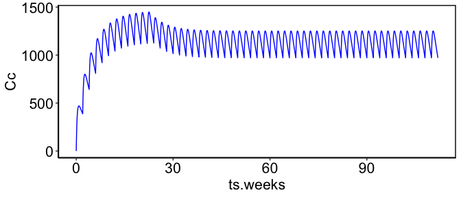

```r
myfig = ggplot() +
        geom_line(data=som_tt$simout, aes(x=ts.weeks,   y=Cc), color="blue")
myfig = prepare_figure('present', myfig)
print(myfig)
```

Initially the concentration in the serum is 0 (`Cc < 900`), so dosing starts at 700. After six months the titration rule is triggered again. At this point the serum concentration is greater greater than 900 so the dose level is reduced to 600. All subsequent measurements are greater than 900 so the dose remains at 600.

*Titration output: som_tt$titration*

[interactive table not shown]

*Titration output: som_tt$titration_history*

[interactive table not shown]

## Monte Carlo Simulations (`analysis_visit_dosing_titration_stochastic.r`)

This example is similar to the last except here we are performing population simulations (20 subjects). The same function (`simulate_subjects()`) is used but setting the `'titrate'` option to `TRUE` tells that function to use the rule-based dosing.

```r
cfg = system_set_option(cfg, group="stochastic", option="nsub",    value=20)
som= simulate_subjects(parameters, cfg)
```

This will add a data a list element called `som$titration` with three fields for each titration rule (`tname`):

- `tt.tname.value` - Value of the rule for the active condition
- `tt.tname.simtime` - Simulation time where the last condition became active
- `tt.tname.timescale` - Simulation time in the time scale the rule was specified in

Each of these fields is a matrix with an entry for each simulation time (column) and each subject (row). In this example these would be accessed through the following list elements:

- *`som$titration$tt.ivdose.simtime`*
- *`som$titration$tt.ivdose.value`*
- *`som$titration$tt.ivdose.timescaletimescale`*

This data structure (`som`) can be collapsed down to a data frame using the `som_to_df` function. With titration simulations a column is added for each rule giving the value of that rule at the indicated time (the first 100 rows are shown):

```r
sdf = som_to_df(cfg, som)
```

[interactive table not shown]

## Performing State/Compartment Resets (`analysis_state_reset.r`)

Along with changing dosing at titration time points, it may also be necessary to directly alter state or compartment values. In this last example we will dose every two weeks and on week 3 we will drop the total drug in the system by 1/2.

This portion covers the IV dosing component:

```r
cfg=system_new_tt_rule(cfg,
                       name       = "ivdose",
                       times      = c(0, 2, 4, 6, 8),
                       timescale  = "weeks")

cfg=system_set_tt_cond(cfg,
                       name       = "ivdose",
                       cond       = 'TRUE',
                       action     = "SI_TT_BOLUS[state='Cc', values=500, times=0]",
                       value      = "5")
```

And this portion reduces the amount of drug in both `Cc` and `Cp` by 1/2 at week 3:

```r
cfg=system_new_tt_rule(cfg,
                       name       = "state_reset",
                       times      = c(3),
                       timescale  = "weeks")
cfg=system_set_tt_cond(cfg,
                       name       = "state_reset",
                       cond       = 'TRUE',
                       action     = "SI_TT_STATE[Cc][0.5*Cc]",
                       value      = "0")
cfg=system_set_tt_cond(cfg,
                       name       = "state_reset",
                       cond       = 'TRUE',
                       action     = "SI_TT_STATE[Cp][0.5*Cp]",
                       value      = "0")
som_tt = run_simulation_titrate(parameters, cfg)
```

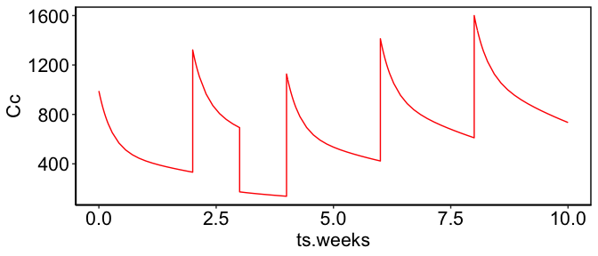

```r
myfig = ggplot() +
        geom_line(data=som_tt$simout, aes(x=ts.weeks,   y=Cc), color="red")
myfig = prepare_figure('present', myfig)
print(myfig)
```

## Contents of `system.txt`

```
# Implementation of the two compartment model from Davda 2014
#
#   Davda, J. P., Dodds, M. G., Gibbs, M. A., Wisdom, W., & Gibbs, J. (2014). A
#   model-based meta-analysis of monoclonal antibody pharmacokinetics to guide
#   optimal first-in-human study design. mAbs, 6(4), 1094-1102.
#   http://doi.org/10.4161/mabs.29095
#
# System Units:
#   mass          [=] nmoles
#   volume        [=] L
#   concentration [=] nM
#   time          [=] day
#

# #-------------#
# | Parameters  |
# #-------------#
# System parameters
#name          value          lower  upper    units  editable grouping
#                             bound  bound
<P> F1         0.744          eps    inf      ---    yes      System
<P> ka         0.282          eps    inf      1/day  yes      System
<P> CL         0.200          eps    inf      L/day  yes      System
<P> Vc         3.61           eps    inf      L      yes      System
<P> Vp         2.75           eps    inf      L      yes      System
<P> Q          0.747          eps    inf      L/day  yes      System
<P> MW         140            eps    inf      kD     yes      System
<PSET:default>  mAb in Humans

# Interindividual Variability
# Taken from Table 3
<IIV:ETAka>    0.416
<IIV:ETAka:LN> ka

<IIV:ETACL>    0.09875
<IIV:ETACL:LN> CL

<IIV:ETAVc>    0.116
<IIV:ETAVc:LN> Vc

```

[output cut: 66 more lines]

```
<EST:LT> Vp; Vc; CL; Q; ka
<EST:P>  Vp; Vc; CL; Q; ka; add_err; prop_err
<OE:C_ng_ml> add=add_err; prop=prop_err
<AMTIFY> Cp; Ap; Vp

# #---------#
# | Options #
# #---------#
# General Options:
# specify different time scales
<TS:min>   24.0*60.0
<TS:days>  1.0
<TS:hours> 24.0
<TS:weeks> 1.0/7.0
<TS:months> 1.0/7.0/4.0
```